# SUM demo

carljpearson

9/7/2018

## Single Usability Metric (SUM) Script Demo

The [SUM method](https://measuringu.com/sum-2/) follows a classic usability testing protocol of metrics collection across tasks. The novelty of the SUM lies in its combination of those metrics through standardized values. This R Markdown document shows the outputs of the script, both data tables and the resulting plots. The [script in its raw form can be found here.](https://github.com/carljpearson/sum_calc_example)

he data are all fake, but made realistic relationships between all sub-measures. If you use the script, it’s easy to drop your own data in (be sure it’s in [long](http://www.cookbook-r.com/Manipulating_data/Converting_data_between_wide_and_long_format/) format). The script will point out where you need to rename variables. You need to be sure time measures are in seconds, completion is binary, and satisfaction should be on a 1-5 scale. It should look like the table below once you’re done.

| par | task | group | comp | sat | time | tspec |
| --- | --- | --- | --- | --- | --- | --- |
| 1 | 1 | 1 | 1 | 4.2 | 30.5 | 60 |
| 1 | 2 | 1 | 1 | 4.4 | 122.5 | 60 |
| 1 | 3 | 1 | 0 | 1.2 | 348.9 | 120 |
| 1 | 4 | 1 | 1 | 4.4 | 726.7 | 300 |
| 2 | 1 | 1 | 1 | 3.9 | 29.9 | 60 |
| 2 | 2 | 1 | 1 | 3.9 | 140.9 | 60 |

### What happens after all these individual lines

#### The script calculates all sub-task raw measures.

- **Task completion**
- LaPlace point estimates
- Adjusted Wald confidence intervals
- **Time-on-task** for completed tasks only
- Geometric average point estimates (to help account for skew)
- Standard confidence intervals
- **Satisfaction**
- Standard average point estimates
- Standard confidence intervals

#### To make it into the SUM, all values are standardized based on a benchmark value.

- **Task completion**
- Converted directly to percentage value based on the pnorm() function
- (A good benchmark is .78, but small samples make it tough to approximate a z-score)
- **Time-on-task** for completed tasks only
- You enter the time you aim for all users to complete the task by to get benchmarks
- Converted to z-score and then percentage equivalent
- **Satisfaction**
- We use a standard benchmark of 4/5 for ‘good’ usability
- Converted to z-score and then percentage equivalent

To make it more accesible to non-researchers, I translate the percentage to an **NPS like score of -100 to 100**. Here’s what your summarized (or summari*s*ed, if you’re using dplyr) table looks like:

Selected example columns/rows

| Group | Task | Raw point estimate | Raw lower confidence | Raw upper confidence | NPS point estimate | NPS lower confidence | NPS upper confidence |
| --- | --- | --- | --- | --- | --- | --- | --- |
| 1 | 1 | 0.82 | 0.67 | 0.94 | 63.64 | 34.61 | 88.80 |
| 1 | 2 | 0.77 | 0.62 | 0.91 | 54.55 | 23.67 | 82.11 |
| 1 | 3 | 0.27 | 0.13 | 0.43 | -45.45 | -74.98 | -13.17 |
| 1 | 4 | 0.45 | 0.28 | 0.63 | -9.09 | -43.11 | 25.48 |
| 2 | 1 | 0.95 | 0.86 | 1.00 | 90.91 | 71.89 | 100.00 |
| 2 | 2 | 0.91 | 0.79 | 1.00 | 81.82 | 58.37 | 100.00 |

#### Next we average the NPS-like values to get our task level SUM scores.

Selected example columns

| Group | Task | NPS point estimate | NPS lower confidence | NPS upper confidence |
| --- | --- | --- | --- | --- |
| 1 | 1 | 22.60 | -6.43 | 50.00 |
| 1 | 2 | -16.86 | -39.81 | 8.83 |
| 1 | 3 | -73.23 | -88.69 | -48.83 |
| 1 | 4 | -47.57 | -70.44 | -17.83 |
| 2 | 1 | 44.25 | 19.09 | 64.42 |
| 2 | 2 | 7.20 | -17.13 | 32.29 |
| 2 | 3 | -46.03 | -69.41 | -15.85 |
| 2 | 4 | -67.55 | -82.40 | -49.47 |

#### We quickly come to our final SUM values.

Selected example columns

| Group | final_SUM | final_SUM_low | final_SUM_hi |
| --- | --- | --- | --- |
| 1 | -28.77 | -51.34 | -1.96 |
| 2 | -15.53 | -37.46 | 7.85 |

#### For our final SUM scores, a table works well because we have just a few data points. For everything else, we may want some plots.

# Plotting

### First up, we can plot our data for each group (version) individually. This is helpful when you want to review how the first round of testing went (version 1, product 1, etc).

### **Raw task** metrics show the data before any transformation.

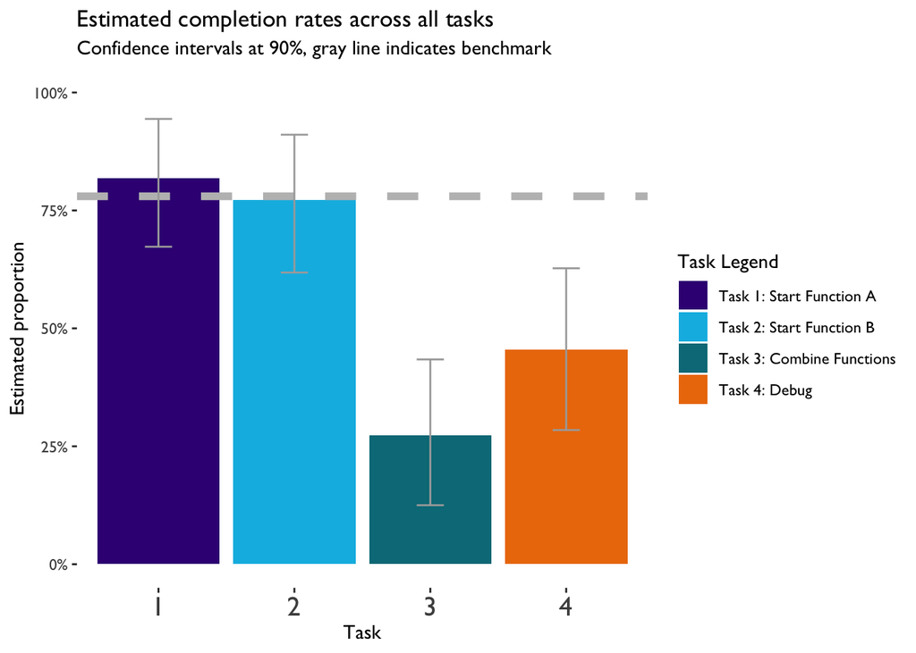

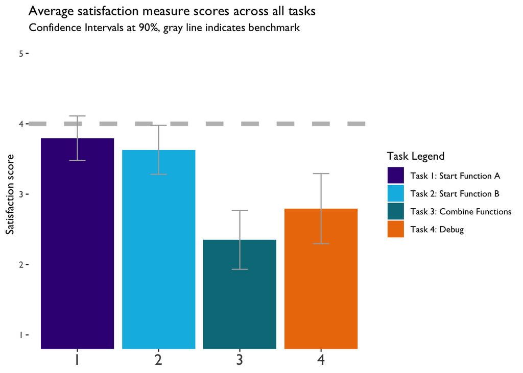

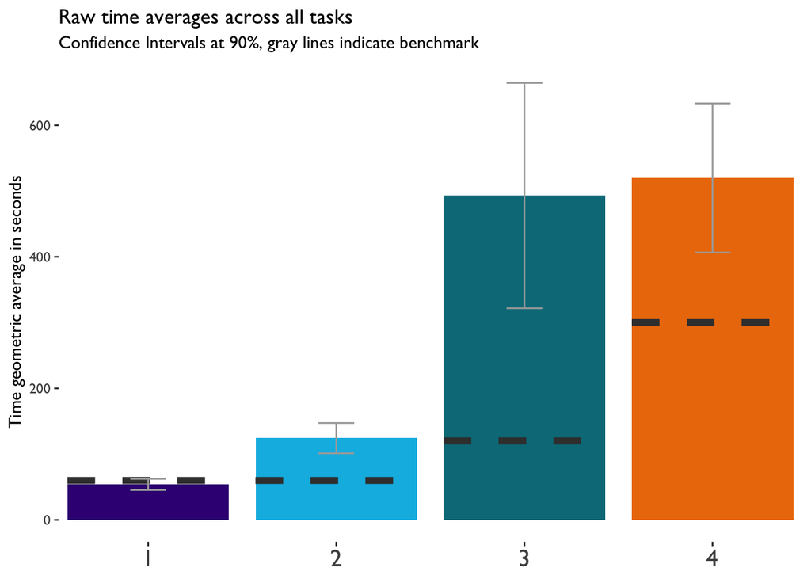

### **Standardized** metrics show our converted values before their summarized by task.

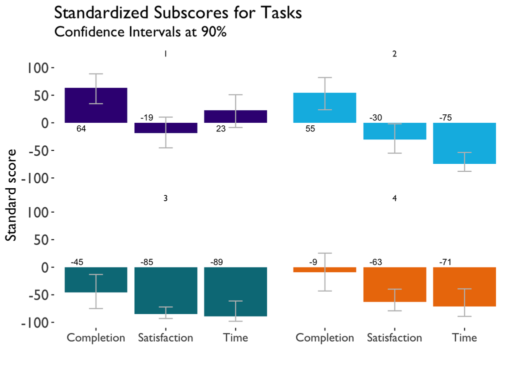

### Finally, we can view our combined task metrics.

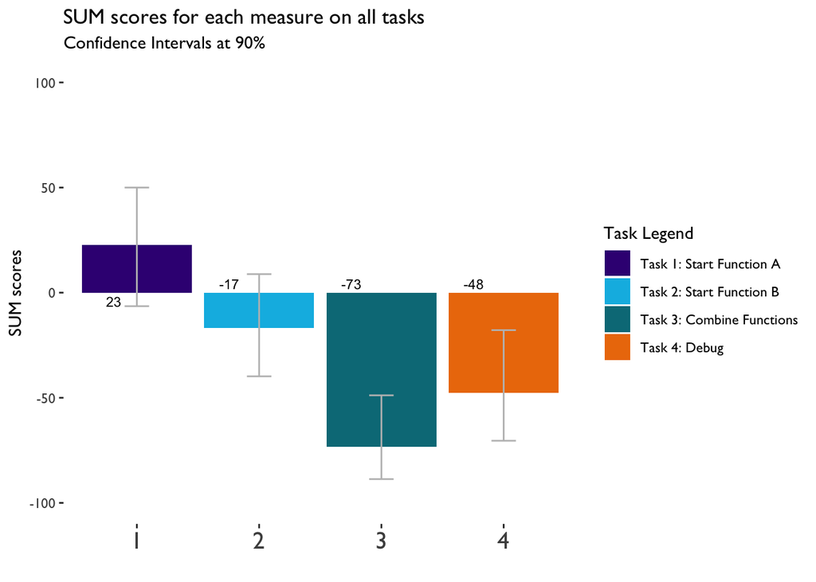